# Russia and NATO Enlargement

How Did Russia Respond to the 2004 NATO Enlargement?

Author

Affiliation

Aliana Sheriff

Melissa High School

Abstract

# 1 Introduction

## 1.1 The Research Question

After the Cold War, NATO expanded eastward and officially invited the Baltic states to join their organization during the Prague Summit in November of 2002, bringing the alliance directly to Russia’s border and intensifying long-standing security tensions between Moscow and the West. Though other scholars have acknowledge hostility present within NATO and Russia during this time, it has never fully been measured with the unique comparison of Russia’s actions between Baltic and non-Baltic states post-Prague Summit. To fill this gap, I utilize a differences in differences model with data from GDELT, a dataset of articles, newspapers, factors related to political communication, which will be critical to asses Russia’s differences in behavior towards other countries.

## 1.2 Historical Context

After the Cold War, NATO expanded eastward. The largest group of new countries officially joined in 2004, after the Prague Summit when seven countries received an invite: Estonia, Latvia, Lithuania, Slovakia, Romania, Bulgaria, and Slovenia. For many of these countries, membership in NATO meant protection against future Russian pressure. Yet, from Moscow’s perspective, not all of these states looked the same.

The Baltic states were former Soviet republics, not just former Warsaw Pact members. Estonia and Latvia each had large Russian-speaking minorities, roughly 25–30 percent of their populations, many of whom faced restrictive citizenship and language laws after independence. Russian leaders claimed a responsibility to defend these communities. Geography made the situation even more sensitive. Tallinn, the capital of Estonia, is less than 200 miles from St. Petersburg, Russia’s second-largest city. Lithuania borders Kaliningrad, where Russia’s Baltic Fleet is stationed. When the Baltic countries joined NATO, the alliance moved directly onto Russia’s frontier.

First, the Baltic states had a common historical past with Russia, being former Soviet republics. Thus, Moscow viewed them as former members of the Russian and Soviet state itself. Losing these states when they joined NATO was not just a geopolitical setback, but a symbolic loss of the empire itself. When the Soviet Union collapsed, Russia struggled with its post-imperial identity. Not only had they lost a significant part of the Union, but they had lost a large part of their presence in Europe as well, leading to an additional loss in European identity. Since the Baltics represented such a significant part of Russia’s past, NATO membership meant that the historically important territory once governed by Moscow was now under a military alliance initially created to counter Moscow. Therefore, the very idea of the Baltic countries joining NATO was a visible confirmation that Russia’s imperial sphere was gone. This emotional and symbolic perspective increases the likelihood of hostility because this territory once belonged to the Soviet Union.

Additionally, because the Baltic countries were part of the Soviet Union, they have a large population of Russian speakers. After claiming independence, citizenship and language policies limited the political representation of some of these residents. Moscow framed this action as discrimination against its people, claiming a right to defend compatriots abroad. The historical past combined with the Russian-speaking population created a justification tool that Moscow could use to criticize Baltic governments.

Proximity is also an important factor towards understanding Moscow’s point of view. The capital of Estonia, Tallinn is less than 200 miles from St. Petersburg and Lithuania borders Kaliningrad, where the Russian Baltic Fleet is stationed. The map below indicates the proximity. In terms of deterrence, this increased the stakes that NATO would invite the Baltic states as a strategic advantages over Russia, as Moscow would care about what happens to the Baltics more than Romania, Bulgaria or Slovakia. Thus, this difference can generate two hypotheses:

1. If Russia reacts more strongly to the Baltics than to other 2004 entrants, then historical ties truly matter to the discussion.
2. If it reacts similarly to both groups, then enlargement itself is likely the key aggravator.

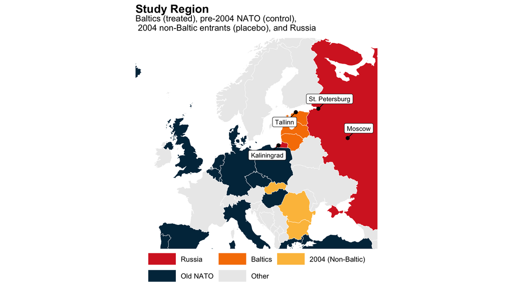

```r
library(dplyr)
library(rnaturalearth)
library(rnaturalearthdata)
library(ggplot2)
library(sf)
library(ggrepel)

# Load world data
world <- ne_countries(scale = "medium", returnclass = "sf")

# Country groups
baltics       <- c("EST", "LVA", "LTU")
nonbaltic2004 <- c("ROU", "BGR", "SVK")
old_nato      <- c("BEL", "CAN", "CZE", "DEU", "DNK", "ESP", "FRA",
                   "GBR", "GRC", "HUN", "ISL", "ITA", "LUX", "NLD",
                   "NOR", "POL", "PRT", "TUR", "USA")
russia        <- c("RUS")

world <- world %>%
  mutate(
    study_group = case_when(
      iso_a3 %in% russia        ~ "Russia",
      iso_a3 %in% baltics       ~ "Baltics",
      iso_a3 %in% nonbaltic2004 ~ "2004 (Non-Baltic)",
      iso_a3 %in% old_nato      ~ "Old NATO",
      TRUE                      ~ "Other"
    ),
    study_group = factor(
      study_group,
      levels = c("Russia", "Baltics", "2004 (Non-Baltic)", "Old NATO", "Other")
    )
  )

map_colors <- c(
  "Russia"            = "#D62828",
  "Baltics"           = "#F77F00",
  "2004 (Non-Baltic)" = "#FCBF49",
  "Old NATO"          = "#003049",
  "Other"             = "grey92"
)

# Cities
cities <- data.frame(
  city = c("Tallinn", "Kaliningrad", "St. Petersburg", "Moscow"),
  lon  = c(24.7536, 20.4522, 30.3351, 37.6173),
  lat  = c(59.4370, 54.7104, 59.9343, 55.7558)
)

cities_sf <- st_as_sf(cities, coords = c("lon", "lat"), crs = 4326)

# Plot
ggplot(world) +
  geom_sf(aes(fill = study_group), color = "white", linewidth = 0.2) +

  # Cities
  geom_sf(data = cities_sf, color = "black", size = 2) +
  geom_label_repel(
    data = cities,
    aes(x = lon, y = lat, label = city),
    size = 3.2,
    fontface = "plain",
    min.segment.length = 0,
    box.padding = 0.4,
    point.padding = 0.3,
    seed = 123
  ) +

  coord_sf(
    xlim = c(-15, 45),
    ylim = c(40, 70),
    expand = FALSE
  ) +

  scale_fill_manual(values = map_colors, name = NULL) +

  labs(
    title = "Study Region",
    subtitle = "Baltics (treated), pre-2004 NATO (control),\n 2004 non-Baltic entrants (placebo), and Russia"
  ) +

  theme_void(base_size = 13) +
  theme(
    legend.position = "bottom",
    legend.box = "horizontal",
    legend.text = element_text(size = 10),
    legend.key.width = unit(1.4, "cm"),
    legend.spacing.x = unit(0.4, "cm"),
    plot.title = element_text(face = "bold", size = 16),
    plot.subtitle = element_text(size = 12, margin = margin(b = 8))
  ) +

  guides(fill = guide_legend(nrow = 2, byrow = TRUE))
```

Since the Baltic states are considered former Soviet imperial territory, from Moscow’s perspective, their loss is seen as a threat. As seen with historical examples, such as Nazi Germany, buffer zones in Eastern Europe has served as strategic depth. Hence, when these territories exit Russia’s sphere in the Cold War, joining NATO in 2004, and host Western military infrastructure, Russia interprets this as loss of defensive depth, and potentially, a threat. Secondly, the close geographic proximity gives the West the ability to place missiles or other weapons, amplifying perceived threats. Lastly, the presence of Russian minorities in the Baltics creates a civilization link, responsibility claim, and a narrative of protection, as discussed earlier. Therefore, when these minorities are now under NATO, Russia now faces cultural erosion, westernization, and the suppression of Russian identity, becoming a cultural and security overlap. Therefore, in regions characterized by shared imperial history, geographic proximity, and co-ethnic populations, NATO expansion is likely to be perceived by Russia not merely as alliance enlargement but as a compound security and civilizational threat.

Romania, Bulgaria, and Slovakia also entered NATO in 2004, but they were different cases as none were former Soviet republics. None bordered Russia and none contained large Russian-speaking populations that Moscow claimed to protect. For Russia, their membership was less symbolically and strategically threatening. This difference creates the central comparison in this paper: if NATO expansion provoked Russia, we should expect a stronger reaction toward the Baltic states than toward the other 2004 entrants.

# 2 Literature Review

## 2.1 NATO Expansion and Security Competition

Debate over NATO enlargement centers on whether eastward expansion is stabilizing or destabilizing European security. Realist scholars often argue that great powers are structurally subject to resist alliance encroachment near their orders. A prominent figure in this regard is John J. Mearsheimer when he argues that NATO expansion into Eastern European significantly altered regional balance of power and threatened the Russian sphere of influence. In his analysis of the Ukraine crisis, (Mearsheimer 2014) argues that Western liberal expansionism provoked predictable backlash by ignoring core principles of great power politics.

Yet, historical accounts complicate this structural explanation. For example, Mary Elise Sarotte (Sarotte 2021), in “Not One Inch,” demonstrates that NATO enlargement was not inevitable but emerged through contingent diplomatic decisions and ambiguous Western assurances in the 1990s. More specifically, in 1990, President Bush had promised not to expand NATO eastward if a reunified Germany was to be under NATO’s protection. However, this promise was not kept, as the Prague Summit invited nations eastward to join NATO. Hence, the war on Ukraine could be seen as a predictable retaliation in response to this broken promise. Similarly, Ronald D. Asmus (Asmus 2002) tells the story of expansion as a deliberate effort to remake NATO for a post–Cold War era, placing Central and Eastern Europe within Western institutions. Such accounts suggest that Russia’s reaction may reflect not just simply structural insecurity but also perceived diplomatic exclusion and betrayal.

Combined, these works highlight that NATO enlargement reshaped both the strategic and political landscape of post-Cold War Europe, creating the conditions under which Russia might signal opposition, change its behavior, or withdraw cooperation.

## 2.2 The Baltics: History, Proximity, and Civilizational Identity

The Baltic states represent a particularly sensitive case in the enlargement debate. As former Soviet republics located directly on Russia’s border, their choice to join NATO combined geographic proximity with historical entanglement. Mark Kramer (Kramer 2002) argued that Baltic enlargement posed unique challenges for NATO-Russian relations because of Russia’s security concerns and the region’s symbolic importance.

Other than military geography, identity politics plays a critical role. Dmitri Trenin (Trenin 2002) characterizes Russia as a state situated between geopolitics and a civilizational identity, arguing that its foreign policy cannot be understood solely in material terms. The presence of Russian-speaking minorities in Estonia and Latvia only deepens this connection. Ammon Cheskin and Angela Kachuyevski (Cheskin and Kachuyevski 2019) show that Russian-speaking minorities in former Soviet republics occupy contested political and identity positions, often serving as focal points for the transnational narratives of protection and belonging.

These historical, geographic, and demographic factors generate the threat perception that NATO expansion into the Baltics may be interpreted as both military encroachment and the erosion of Russia’s cultural and civilizational sphere.

## 2.3 Signaling, Coercion, and Limited Escalation

If the expansion of NATO creates perceptions of threats, the question remains: how should Russia respond? Classic signaling theory can provide an answer. Thomas C. Schelling (Schelling 1966) explains that states use often use threats, demonstrations, and limited actions to influence adversaries without triggering uncontrolled escalation. James J. Fearon (Fearon 1997) builds on this logic, distinguishing “tying hands” and “sinking costs” as mechanisms through which states can credibly resolve signals.

Applied to the expansion of NATO, these frameworks suggest that Russia may increase rhetorical hostility or symbolic confrontation to signal dissatisfaction while avoiding potentially costly military escalation. Verbal conflict then serves as a low-risk signaling mechanism, especially when direct confrontation risks invoking NATO’s collective defense commitments under Article 5.

## 2.4 Alliances and the Constraint of Article 5

The deterrent power of alliances further shapes expected behavior. Brett Ashley Leeds (Leeds 2003) found that military alliances significantly reduces the likelihood of aggression towards member states. Thus, NATO’s Article 5 commitment imposes significant constraints on Russia’s potential use of force against newly admitted members, in this case, the Baltic states.

Under this logic, material conflict should remain limited following Baltic accession, even if tensions rise. Instead, if Russia were to escalate, Moscow may shift its strategy towards tactics that do not involve use of military like diplomatic pressure, economic leverage, or rhetorical confrontation. This is consistent with signaling theory and alliance deterrence findings.

## 2.5 Interactions: Event Data and Behavioral Change

To evaluate these theoretical expectations, this study relies on event data cataloging Russia’s interactions with NATO member states. The Global Database of Events, Language, and Tone (GDELT) provides systematic coding of verbal and material interactions across countries over time. As described by Kalev Leetaru and Philip A. Schrodt (Leetaru and Schrodt 2013), GDELT allows for a fine-grained, in-depth analysis of conflict, cooperation, and tone across international dyads.

By differentiating between verbal conflict, material conflict, and cooperation events this study is able to test whether NATO expansion altered the composition of volume of Russia’s interactions. Specifically, it assesses whether expansion produced:

1. increased verbal signaling
2. stable material conflict due to deterrence, or
3. broader relational withdrawal

## 2.6 Conclusion of the Literature

The existing literature suggests three competing and non-mutually exclusive expectations. Realist and historical perspectives predict increased tension following NATO expansion. Identity-based analyses emphasize the particular sensitivity of the Baltic case, as these states were once part of the Soviet Union. Signaling and alliance theory imply that escalation may be more rhetorical than military due to strong deterrent constraints like Article 5 of NATO. The present study combines these viewpoints by empirically evaluating how Russia’s verbal, material, and cooperative interactions changed following NATO’s 2002 enlargement announcement.

# 3 Theory and Hypothesis

H1 — Rhetorical Escalation: If NATO enlargement to the Baltic states provoked Russia into signaling dissatisfaction, we should observe a measurable increase in the share and volume of verbal conflict directed toward the Baltic states following the 2002 Prague Summit relative to the control group.

H2 — Material Restraint: If NATO’s Article 5 collective defense commitment deters direct military confrontation, material conflict toward the Baltic states should remain stable or unchanged following enlargement, even if rhetorical tensions rise.

H3 — Relational Withdrawal: If Russia responded to enlargement by disengaging entirely rather than escalating, we should observe a broad decline across all interaction types, both verbal and material conflict and overall event volume, reflecting a deliberate cooling of the relationship rather than targeted hostility.

# 4 Methods

## 4.1 What is the Data?

This study draws on GDELT 1.0, a large-scale event dataset that automatically codes international interactions from global news sources into structured event records. Each observation captures Russia as the acting state, a target country, an interaction type, and a date. The final dataset comprises 34 countries observed across 108 months from January 2000 through December 2008, forming a balanced panel at the country-month level. Two categories of outcome variables are used: event counts, measuring the raw volume of verbal conflict, material conflict, and cooperative interactions in a given country-month, and shares, measuring each conflict type as a proportion of Russia’s total interactions with that country in that month. An example of the data is shown below:

Data Structure Overview

| Description | Explanation |
| --- | --- |
| Data Source | GDELT event data (news-coded international interactions) |
| Unit of Analysis | Country-month observation |
| Actor | Russia |
| Target | target_country variable |
| Time Unit | year_month variable |

Example Country-Month Observations

| target_country | year_month | verbal_conflict | material_conflict |
| --- | --- | --- | --- |
| BEL | 2000-01-01 | 1 | 2 |
| BEL | 2000-02-01 | 1 | 0 |
| BEL | 2000-03-01 | 0 | 0 |
| BEL | 2000-04-01 | 0 | 0 |
| BEL | 2000-05-01 | 13 | 0 |
| BEL | 2000-06-01 | 7 | 2 |
| BEL | 2000-07-01 | 0 | 1 |
| BEL | 2000-08-01 | 0 | 0 |

## 4.2 Estimation

The primary estimator is a two-way fixed effects difference-in-differences model:

$$VerbalShare_{it} =
\alpha +
\beta (Baltic_i \times Post2002_t) +
\gamma_i +
\delta_t +
\varepsilon_{it}$$

## 4.3 Groups

The Baltic states, Estonia, Latvia, and Lithuania, constitute the treated group. Longstanding NATO members including the United States, France, and the United Kingdom serve as the control group, providing the counterfactual trajectory against which Baltic outcomes are compared. Romania, Bulgaria, and Slovakia form a placebo group: they joined NATO in the same 2004 enlargement round as the Baltic states but share none of the historical, geographic, or demographic characteristics that made the Baltic case symbolically and strategically distinct for Moscow. Finding no treatment effect among the placebo group would strengthen confidence that any estimated Baltic effect reflects those specific characteristics rather than NATO enlargement in general.

# 5 Results

## 5.1 Descriptive Patterns

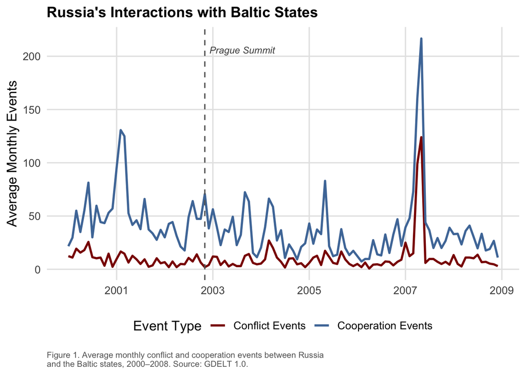

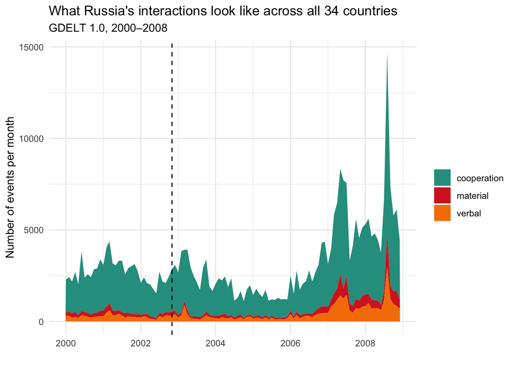

## 5.2 Share Results

Figure 3 presents verbal conflict share by group over time, smoothed using a loess curve to reduce month-to-month volatility. The Baltic states show a consistently higher baseline and a more visible upward drift after 2004, while non-Baltic 2004 entrants and longstanding NATO members remain comparatively flat throughout. At first glance this divergence appears to reflect increased Russian hostility toward the Baltics specifically. However, as the count decomposition in the following section demonstrates, this rise in share does not reflect an increase in the volume of conflict events. It reflects a decline in cooperative interactions, which reduced the total number of Russia-Baltic exchanges and mechanically inflated the hostile share of what remained. The divergence is real, but its meaning is disengagement rather than escalation. The fact that non-Baltic 2004 entrants show no comparable pattern further suggests that whatever drove this shift was specific to the Baltic case, geography, historical incorporation, and identity dynamics, rather than NATO enlargement as an institutional event.

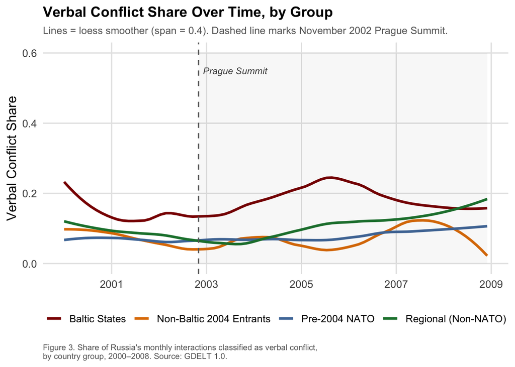

## 5.3 Count Decomposition: The Denominator Effect

A verbal conflict share is a fraction: conflict events divided by total interactions. That fraction can rise for two very different reasons: because the numerator grew, meaning Russia became more hostile, or because the denominator shrank, meaning Russia simply interacted less overall. Figure 4 presents the full decomposition, plotting difference-in-differences estimates separately for conflict counts, cooperation counts, and conflict shares side by side. The count estimates for verbal and material conflict are small and statistically indistinguishable from zero, indicating no meaningful increase in hostile events toward the Baltic states following the Prague Summit. The cooperation count estimate, by contrast, is negative, reflecting the decline in cooperative interactions visible in the descriptive figures above. With fewer total interactions, hostility constituted a larger share of what remained, producing the apparent share increase without any underlying escalation in aggressive behavior. The appearance of escalation was, in fact, disengagement.

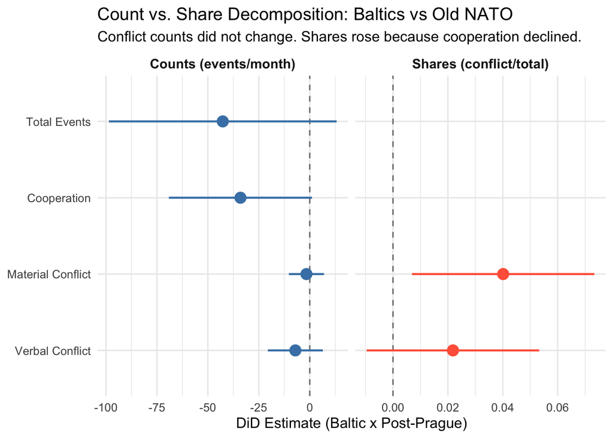

## 5.4 Event Studies

The event study graph presents dynamic treatment effects relative to 2002. Pre-treatment coefficients for 2000 and 2001 are statistically indistinguishable from zero, supporting the parallel trends assumption and lending credibility to the causal design. Beginning in 2003, the Baltic states exhibit a positive increase in Russia’s verbal conflict share relative to the control group, with the effect persisting through 2005 before gradually declining toward 2006. This timing is consistent with the cooperation decline documented in the count decomposition, as cooperative interactions fell during the accession window, the share of hostile events rose as a mechanical consequence. The event study therefore captures the timing of Russia’s behavioral shift accurately, but the nature of that shift is disengagement rather than escalation. Russia did not become more aggressive toward the Baltics, it became less engaged, and the share pattern reflects that withdrawal.

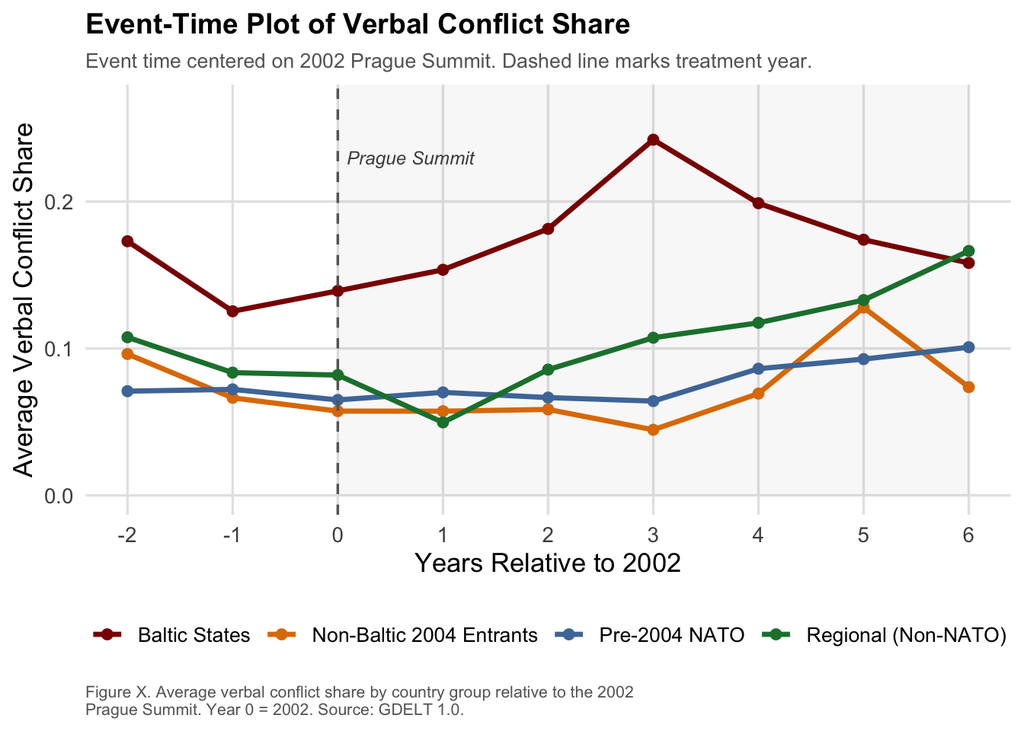

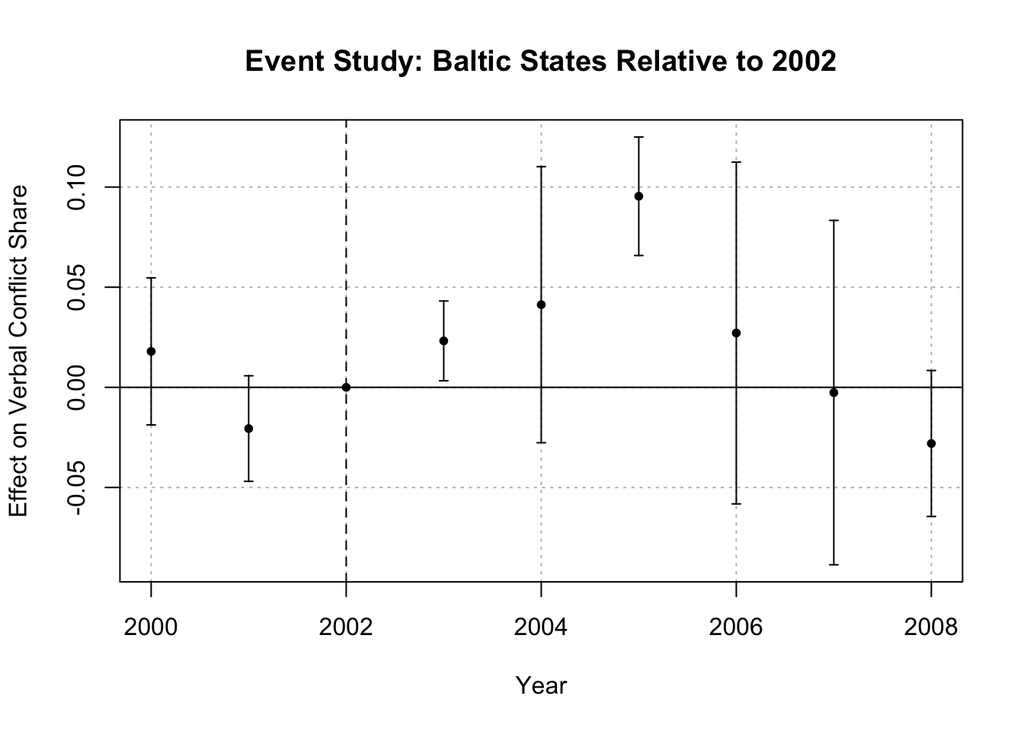

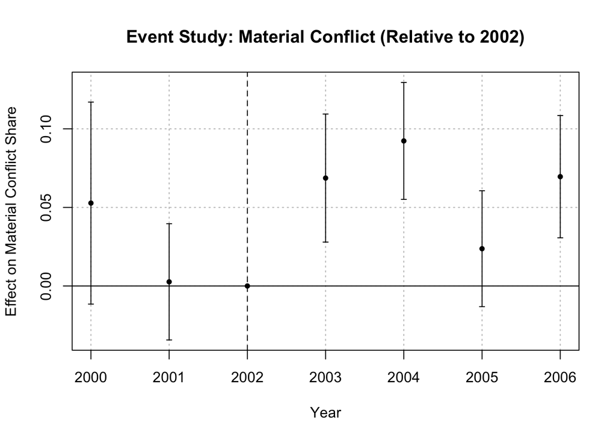

## 5.5 Placebo Test

|  | Verbal Count | Coop. Count | Verbal Share |
| --- | --- | --- | --- |
| placebo_ind:post | -8.940* | -21.183 | -0.012 |
|  | (4.948) | (13.553) | (0.024) |
| Num.Obs. | 2376 | 2376 | 2179 |
| R2 | 0.405 | 0.604 | 0.112 |

* p < 0.1, ** p < 0.05, *** p < 0.01  
Placebo group: Romania, Bulgaria, Slovakia. Control group: Pre-2004 NATO members. Same specification as main results. Standard errors clustered by country.

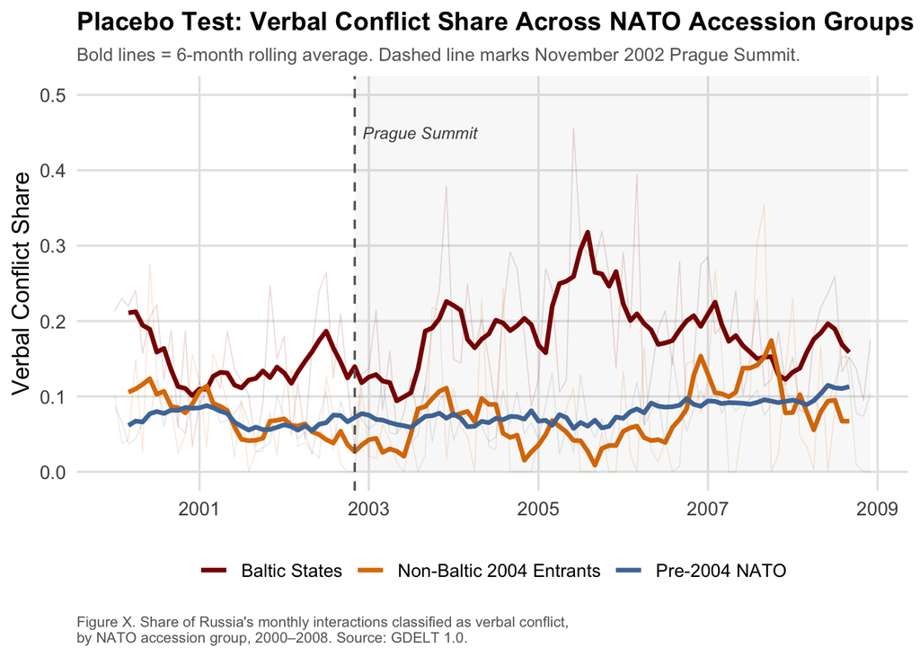

## 5.6 Summary of Findings

Russia did not escalate toward the Baltic states following NATO enlargement. Conflict counts remained largely flat while cooperative interactions declined, producing a rise in verbal conflict share that reflected disengagement rather than aggression. The count decomposition establishes that the share increase was a compositional artifact, a falling denominator, not a rising numerator. The event studies confirm that this shift was concentrated in the post-2002 accession window. The placebo test confirms it was Baltic-specific: Romania, Bulgaria, and Slovakia show no comparable pattern despite joining NATO in the same enlargement round. Taken together, the evidence points toward a deliberate but low-cost withdrawal from cooperative engagement rather than the rhetorical signaling or material confrontation that realist backlash accounts would predict.

# 6 Discussion

## 6.1 Reinterpreting the Results

The share increase documented in the DiD estimates should not be read as evidence of escalation. As the count decomposition demonstrates, Russia’s verbal conflict toward the Baltic states did not rise in absolute terms following the Prague Summit, cooperative interactions fell while conflict remained stable, mechanically inflating the hostile share of what remained. This distinction matters theoretically. A genuine escalation would require an increase in conflictual behavior. What the data show instead is a contraction of the overall relationship, with cooperation bearing the cost of that contraction. The correct interpretation is disengagement, not aggression.

## 6.2 Why Did Cooperation Decline?

Three explanations are plausible, and the data cannot definitively distinguish between them. First, the decline may reflect deliberate punishment. Russia froze out the Baltic states as a form of low-cost retaliation that signaled displeasure without crossing the threshold that NATO’s Article 5 collective defense commitment would trigger. Second, it may reflect a natural wind-down of the relationship: once the accession decision was made and irreversible, there was simply less to negotiate or cooperate about, and interaction volumes fell accordingly. Third, the pattern may partly reflect a media shift. GDELT captures what journalists report, and reporters may have lost interest in routine Russia-Baltic cooperation stories after accession was settled, deflating the measured cooperation count without any underlying change in actual diplomatic behavior. All three mechanisms are consistent with the observed pattern, and distinguishing between them would require data beyond what GDELT provides.

## 6.3 Limitations

Several limitations should temper how broadly these findings are interpreted. Only three countries comprise the treated group, meaning the results are suggestive rather than definitive idiosyncratic features of Estonia, Latvia, or Lithuania could be driving the pattern rather than Baltic membership as a category. GDELT measures media coverage of international interactions rather than diplomatic behavior directly, introducing potential noise from editorial decisions and coverage gaps. The pre-treatment period is short, spanning only two years before the Prague Summit, which limits the strength of the parallel trends assumption even though pre-treatment coefficients are close to zero. Finally, the analysis is bounded to a single enlargement episode, making direct generalization to later periods difficult without additional theoretical scaffolding.

# 7 Conclusion

This study set out to evaluate whether NATO enlargement to the Baltic states provoked escalatory responses from Russia. The answer is no, but the more interesting finding is what did happen instead. Russia disengaged. Cooperative interactions with the Baltic states declined following the 2002 Prague Summit while conflict counts remained largely flat, producing a rise in verbal conflict share that reflected a shrinking relationship rather than a more hostile one. A placebo test confirms this pattern was Baltic-specific: Romania, Bulgaria, and Slovakia, who joined NATO in the same enlargement round, show no comparable behavioral shift.

This finding reframes the theoretical debate. Mearsheimer’s structural realist prediction of strong backlash finds no support in the material conflict data, and the apparent rhetorical escalation dissolves once the denominator effect is accounted for. The more apt theoretical lens is neither signaling nor confrontation but a form of low-cost relational punishment. Russia withdrew cooperative engagement in a way that registered dissatisfaction without triggering the collective defense response that overt aggression would have invited under Article 5.

The contrast with Ukraine is worth noting briefly. Russia disengaged from the Baltic states after they joined NATO, but later invaded Ukraine, which had not. The difference in response may reflect precisely the alliance guarantee that Baltic membership provided. Article 5 raised the cost of military action high enough that disengagement became the rational substitute. Whether the same logic would have constrained Russia had Ukraine joined NATO remains one of the most consequential counterfactuals in contemporary international relations.

What remains unanswered is whether the disengagement documented here was a deliberate strategic choice, a natural wind-down of a relationship with diminishing diplomatic content, or an artifact of shifting media attention. Resolving that question would require data on actual diplomatic contact, trade flows, and bilateral communications that go beyond what event-based datasets like GDELT can provide. That remains an important direction for future research.

# 8 AI Transparency Statement

AI was used to resolve syntactical errors in R code. This primarily concerned the specification of regression models and the formatting of graphical output. The role of AI was limited to correcting technical implementation issues, ensuring that the code in graphs and models was executed properly. All substantive decisions regarding model choice, robustness checks, coding strategy, and interpretation of results were determined by the author.

The intellectual contribution of this paper, including its theoretical framing, methodological design, and empirical analysis, rests with the author. AI assistance was confined to technical functions. I remain solely responsible for the scholarly content, interpretation of findings, and framing the contribution to the literature.

# 9 References

Asmus, Ronald D. 2002. *Opening NATO’s Door: How the Alliance Remade Itself for a New Era*. New York: Columbia University Press.

Cheskin, Ammon, and Angela Kachuyevski. 2019. “The Russian-Speaking Populations in the Post-Soviet Space: Language, Politics and Identity.” *Europe-Asia Studies* 71 (1): 1–23. https://doi.org/10.1080/09668136.2018.1529467.

Fearon, James D. 1997. “Signaling Foreign Policy Interests: Tying Hands Versus Sinking Costs.” *Journal of Conflict Resolution* 41 (1): 68–90. https://doi.org/10.1177/0022002797041001004.

Kramer, Mark. 2002. “NATO, the Baltic States and Russia: A Framework for Sustainable Enlargement.” *International Affairs* 78 (4): 731–56. https://doi.org/10.1111/1468-2346.00277.

Leeds, Brett Ashley. 2003. *Alliance Politics and Territorial Conflict*. Cambridge, UK: Cambridge University Press.

Leetaru, Kalev, and Philip A. Schrodt. 2013. “GDELT: Global Data on Events, Location, and Tone.” *PACIFIC Symposium on Biocomputing*, 175–86. https://www.gdeltproject.org/.

Mearsheimer, John J. 2014. “Why the Ukraine Crisis Is the West’s Fault: The Liberal Delusions That Provoked Putin.” *Foreign Affairs* 93 (5): 77–89. https://www.foreignaffairs.com/articles/russia-fsu/2014-08-18/why-ukraine-crisis-west-s-fault.

Sarotte, Mary Elise. 2021. *Not One Inch: America, Russia, and the Making of Post–Cold War Stalemate*. The Henry l. Stimson Lectures Series. New Haven, CT: Yale University Press.

Schelling, Thomas C. 1966. *The Strategy of Conflict*. Cambridge, MA: Harvard University Press.

Trenin, Dmitri. 2002. *The End of Eurasia: Russia on the Border Between Geopolitics and Globalization*. Washington, D.C.: Carnegie Endowment for International Peace.